# Modeling- Optimizing For Tournament Structure

- Robert Shaw, Sean Coleman, Spencer Evans, Daniel Alpert
- CS109a Project- Data Driven March Madness

In this file, we tune our model to the sturcture of the tournament. Using a simulation method, we will attempt to approxiate the maximum expected score (i.e. number of point under the ESPN scoring method).

We also present methods for biasing our predictions towards making "unique" brackets (i.e. those that are much different from choosing the higher seed). We also allow the location of the bias to change (i.e. induce a lot of early round upsets or late round upsets).

```python
import march_madness_classes as mmc
import march_madness_games as mmg
import march_madness_models as mmm
import march_madness_train_and_tune as mmtt

import pandas as pd
import numpy as np
import matplotlib
import matplotlib.pyplot as plt
%matplotlib inline

from sklearn.preprocessing import StandardScaler
from sklearn.linear_model import LogisticRegression as LogReg
from sklearn.linear_model import Lasso as Lasso
from sklearn.ensemble import RandomForestClassifier as random_forest
```

```python
# read in the dataset
seeds = pd.read_csv("datasets/kaggle_data/TourneySeeds.csv")
slots = pd.read_csv("datasets/kaggle_data/TourneySlots.csv")
games = pd.read_csv("datasets/kaggle_data/TourneyCompactResults.csv")

seeds_arr = mmg.filter_into_seasons(seeds)
slots_arr = mmg.filter_into_seasons(slots)
games_arr = mmg.filter_into_seasons(games)
```

```python
# extract predictors, chosen from the variable selection notebook
markov          = pd.read_csv("datasets/our_data/stationary", index_col=0)
rpi             = pd.read_csv("datasets/our_data/rpi", index_col=0)
bad_losses      = pd.read_csv("datasets/our_data/bad_losses", index_col=0)

# seeds
seed_matrix_df  = pd.read_csv("datasets/our_data/team_summary_data/seeds_matrix", index_col=0)
```

```python
# get data into correct format
predictor_names = ["min_index_id", "max_index_id", "markov","rpi","bad_losses"]

# package the predictors into an array
predictor_dfs = [markov, rpi, bad_losses]
```

```python
train_test_arr = []

window   = 3
min_year = 2001
max_year = 2014

year_range = range(min_year, max_year)

# generate our train test split for each year
for year in year_range:
    # do the split for the current year
    train_test_tuple = mmtt.train_test_split(window,
                                             year,
                                             seeds_arr,
                                             slots_arr,
                                             games_arr,
                                             predictor_names,
                                             predictor_dfs)

    # add to our array
    train_test_arr.append(train_test_tuple)
```

```python
reload(mmm)
```

```
<module 'march_madness_models' from 'march_madness_models.py'>
```

```python
# our cross validated value of c, from variable selection notebook
c = 1
variables = ["markov","rpi","bad_losses"]

# models and scalers to be fit
models  = []
scalers = []

for year in year_range:
        # get train data
        train_x = train_test_arr[year - min_year][0][variables]
        train_y = train_test_arr[year - min_year][1].values[:, 0]

        # get cross validation set
        cross_x = train_test_arr[year - min_year][2][variables]
        cross_y = train_test_arr[year - min_year][3].values[:, 0]

        # scaling
        scaler = StandardScaler().fit(train_x)
        scaled_train_x = scaler.transform(train_x)
        scaled_cross_x = scaler.transform(cross_x)

        # init model
        model = LogReg(C=c)

        # fit model
        model.fit(scaled_train_x, train_y)

        # append to our lis of models
        models.append(model)
        scalers.append(scaler)
```

## 1) Simulator vs Greedy

We will first test our simulation method - in which we try to find the optimal score over the entire bracket. As a baseline, we will use an alternative greedy method, in which we make the locally optimal decision to maximize score in each round. We expect these results to be almost the exact same.

#### Setup and Train Simulations

```python
# setup simulator
simulators = []

i = 0
# iterate years
for year in year_range:
    # get data needed
    seeds_year = seeds_arr[year-1985]
    slots_year = slots_arr[year-1985]
    games_year = games_arr[year-1985]

    # setup head to head model
    head_to_head_model_year = mmm.ModelPredictor(models[i], scalers[i], predictor_dfs, year, seeds_year, simulation=True)

    # setup simulator
    simulators.append(mmc.Simulator(seeds_year, slots_year, head_to_head_model_year))

    i = i + 1
```

```python
# run simulations
i = 0
for year in year_range:
    # run simulation
    points = simulators[i].simulate_tournament(300)

    # predict bracket based on the simulation
    bracket = simulators[i].predict_tournament()

    i = i + 1

    print year
```

```
2001
2002
2003
2004
2005
2006
2007
2008
2009
2010
2011
2012
2013
```

#### Setup and Train Greedy/Low Seed Baseline

```python
# run greedy and top seed tourneys
year = min_year
greedy_tourneys   = []
top_seed_tourneys = []
actual_tourneys   = []

# analyze results for all simulations
i = 0
for year in year_range:
    # get data from our db
    seeds_year = seeds_arr[year-1985]
    slots_year = slots_arr[year-1985]
    games_year = games_arr[year-1985]

    # get actual models
    actual_model = mmm.ActualTournament(games_arr[year-1985])
    actual_tourneys.append(mmc.Tournament(seeds_year, slots_year, actual_model, include_scoring_dif=False))

    # get greedy models
    greedy_model = mmm.ModelPredictor(models[i], scalers[i], predictor_dfs, year, seeds_year, simulation=False)
    greedy_tourneys.append(mmc.Tournament(seeds_year, slots_year, greedy_model, include_scoring_dif=False))

    # get top seed models
    top_seed_model = mmm.BasicPredictor()
    top_seed_tourneys.append(mmc.Tournament(seeds_year, slots_year, top_seed_model, include_scoring_dif=False))

    year = year + 1
    i = i + 1
```

#### Scoring - Under ESPN Standard Scoring

```python
year = min_year

simulator_scores = np.zeros(len(year_range))
simulator_accuracys = np.zeros(len(year_range))

# analyze results for all simulations
i = 0
for simulator in simulators:
    # get data from our db
    seeds_year = seeds_arr[year-1985]
    slots_year = slots_arr[year-1985]
    games_year = games_arr[year-1985]

    # get actual models
    actual_model = mmm.ActualTournament(games_arr[year-1985])
    actual_tourney = mmc.Tournament(seeds_year, slots_year, actual_model, include_scoring_dif=False)

    # score tournament
    simulator_scores[i], simulator_accuracys[i] = simulator.score_tournament(actual_tourney, print_res=False)

    year = year + 1
    i = i + 1
```

```python
# buffers
greedy_scores = np.zeros(len(year_range))
greedy_accuracys = np.zeros(len(year_range))

top_seed_scores = np.zeros(len(year_range))
top_seed_accuracys = np.zeros(len(year_range))

# analyze results
year = min_year
i = 0
for i in range(len(year_range)):
    # get data from our db
    seeds_year = seeds_arr[year-1985]
    slots_year = slots_arr[year-1985]
    games_year = games_arr[year-1985]

    # get models
    actual_tourney = actual_tourneys[i]
    greedy_tourney = greedy_tourneys[i]
    top_seed_tourney = top_seed_tourneys[i]

    # score tournaments
    greedy_scores[i], greedy_accuracys[i] = greedy_tourney.score_tournament(actual_tourney, print_res=False)
    top_seed_scores[i], top_seed_accuracys[i] = top_seed_tourney.score_tournament(actual_tourney, print_res=False)

    year = year + 1
    i = i + 1
```

```
Avg Score Top Seed   : 863.846153846
Avg Score Greedy     : 960.0
Avg Score Simulation : 943.076923077
```

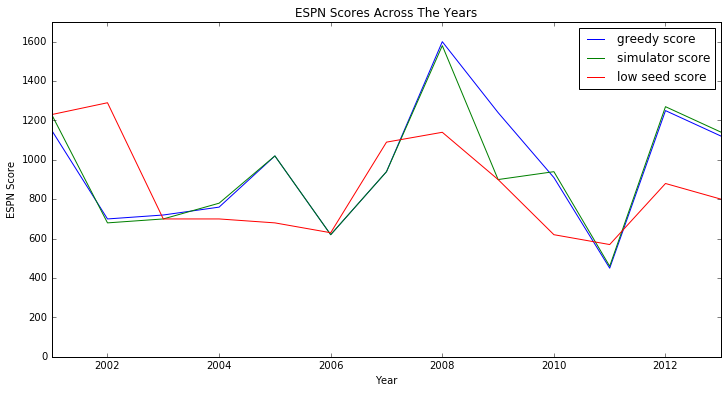

```python
fig = plt.figure(figsize=(12,6))
ax = fig.add_subplot(111)
ax.plot(year_range, greedy_scores, color="b", label="greedy score")
ax.plot(year_range, simulator_scores, color="g", label="simulator score")
ax.plot(year_range, top_seed_scores, color="r", label="low seed score")
ax.set_xlim([2001, 2013])
ax.set_ylim([0, 1700])
ax.set_xlabel("Year")
ax.set_ylabel("ESPN Score")
ax.set_title("ESPN Scores Across The Years")
ax.legend()

print "Avg Score Top Seed   : {}".format(np.average(top_seed_scores))
print "Avg Score Greedy     : {}".format(np.average(greedy_scores))
print "Avg Score Simulation : {}".format(np.average(simulator_scores))
```

#### Uniqueness

```python
n = len(greedy_tourneys)

greedy_n_dif = np.zeros(n)
greedy_n_correct = np.zeros(n)
greedy_n_other_correct = np.zeros(n)

greedy_n_dif_sim = np.zeros(n)
greedy_n_correct_sim = np.zeros(n)
greedy_n_other_correct_sim = np.zeros(n)

simulator_n_dif = np.zeros(n)
simulator_n_correct = np.zeros(n)
simulator_n_other_correct = np.zeros(n)

# iterate through our entire list
for i in range(n):
    # comapre
    greedy_n_dif_sim[i], greedy_n_correct_sim[i], greedy_n_other_correct_sim[i] = greedy_tourneys[i].compare_to_dif_tournament(actual_tourneys[i], simulators[i].tournament_prediction, print_res=False)

    greedy_n_dif[i], greedy_n_correct[i], greedy_n_other_correct[i] = greedy_tourneys[i].compare_to_dif_tournament(actual_tourneys[i], top_seed_tourneys[i], print_res=False)

    simulator_n_dif[i], simulator_n_correct[i], simulator_n_other_correct[i] = simulators[i].tournament_prediction.compare_to_dif_tournament(actual_tourneys[i], top_seed_tourneys[i], print_res=False)
```

```
Avg N Games Dif Simulator : 8.0
Avg N Games Dif Greedy    : 8.46153846154
```

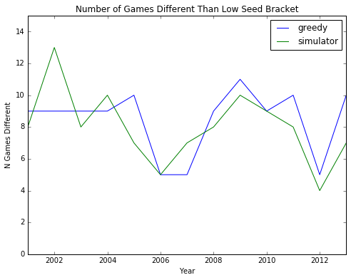

```python
fig = plt.figure(figsize=(8,6))
ax = fig.add_subplot(111)
ax.plot(year_range, greedy_n_dif, color="b", label="greedy")
ax.plot(year_range, simulator_n_dif, color="g", label="simulator")
ax.set_xlim([2001, 2013])
ax.set_ylim([0,15])
ax.set_xlabel("Year")
ax.set_ylabel("N Games Different")
ax.set_title("Number of Games Different Than Low Seed Bracket")
ax.legend()

print "Avg N Games Dif Simulator : {}".format(np.average(simulator_n_dif))
print "Avg N Games Dif Greedy    : {}".format(np.average(greedy_n_dif))
```

Maximizing expected score is not our only goal - we also care about the uniqueness of our bracket. In order to perform very well in an office pool or ESPN bracket challenge, our prediction needs to be different than everyone elses. Getting in the 65 percentile every year is not an ideal strategy. Rather, we would prefer a high-variance strategy which either does very well or very poorly. We define uniqueness to be the number of games different than just picking the lower seed to win every game. The "low-seed" bracket is our "standard" bracket that most people will have. As we can see, our unbiased models, which simply select based on the head to head model that we trained (see Model Selection file) only predict about 8.5 games differently (out of 63 total games) than the top seed bracket. As such, we need a way to bias our predictions to maximize uniqueness, without sacrificing too much expected accuracy.

```
Avg N Games Dif Simulator vs Greedy: 2.69230769231
```

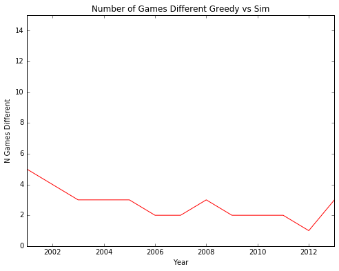

```python
fig = plt.figure(figsize=(8,6))
ax = fig.add_subplot(111)
ax.plot(year_range, greedy_n_dif_sim, color="r")
ax.set_xlim([2001, 2013])
ax.set_ylim([0,15])
ax.set_xlabel("Year")
ax.set_ylabel("N Games Different")
ax.set_title("Number of Games Different Greedy vs Sim")
ax.legend()

print "Avg N Games Dif Simulator vs Greedy: {}".format(np.average(greedy_n_dif_sim))
```

The greedy and the simulation only pick about 2.7 games differently, on average.

## 2) Increase Uniqueness

- To increase uniqueness, we need to increase the number of predicted upsets. To do this, we will change the threshold for predicting an upset. For example, with a bias of .05, if we think there is a 45% chance of an upset, we will predict an upset in that game.
- To start, we will see how model performs with various amounts of bias.

```python
biases = [0, .01, .02, .03, .04, .05, .06, .07, .08, .09, .1, .11, .12, .13, .14, .15, .16, .17, .18, .19, .2]
```

```python
# fit biased models
biased_tourneys = []
i = 0
for year in year_range:
    # get data needed
    seeds_year = seeds_arr[year-1985]
    slots_year = slots_arr[year-1985]
    games_year = games_arr[year-1985]

    biased_tourneys_year_i = []

    # iterate biases
    for bias in biases:
        # setup head to head model, with bias
        biased_model = mmm.ModelPredictor(models[i],
                                         scalers[i],
                                         predictor_dfs,
                                         year,
                                         seeds_year,
                                         simulation=False,
                                         higher_seed_bias=True,
                                         higher_seed_bias_delta=bias)


        biased_tourneys_year_i.append(mmc.Tournament(seeds_year, slots_year, biased_model, include_scoring_dif=False))

    biased_tourneys.append(biased_tourneys_year_i)

    i = i + 1
```

```python
scores_biased_tourneys = np.zeros((len(biased_tourneys), len(biased_tourneys[0])))

# score biased models
i = 0
for year in year_range:
    j = 0

    # actual results
    actual_tourney = actual_tourneys[i]

    # get data needed
    seeds_year = seeds_arr[year-1985]
    slots_year = slots_arr[year-1985]
    games_year = games_arr[year-1985]

    for bias in biases:
        # score the biased models
        scores_biased_tourneys[i, j], x = biased_tourneys[i][j].score_tournament(actual_tourney)

        j = j + 1

    i = i + 1
```

```python
# std of scores
std_score = np.std(scores_biased_tourneys, axis=0)
std_score
```

```
array([ 301.43247745,  298.29297381,  300.01577868,  301.86991203,
        306.86041388,  283.23991963,  274.08589333,  285.07654946,
        254.51659715,  283.34435528,  290.72445728,  268.50451496,
        272.52273126,  274.71771418,  259.48515252,  258.34246341,
        254.9324078 ,  324.67370967,  340.28007956,  364.07619984,
        350.70512235])
```

```python
avg_score = np.average(scores_biased_tourneys, axis=0)
avg_score[0]
```

```
960.0
```

```python
max_score = np.max(scores_biased_tourneys, axis=1)
max_score
```

```
array([ 1220.,   770.,   740.,   880.,  1190.,  1150.,   940.,  1610.,
        1240.,   980.,   480.,  1360.,  1120.])
```

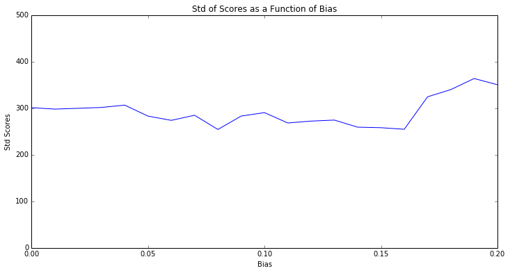

```python
fig = plt.figure(figsize=(12,6))
ax = fig.add_subplot(111)
ax.plot(biases, std_score)
ax.set_xlim([0, .2])
ax.set_ylim([0, 500])
ax.set_xlabel("Bias")
ax.set_ylabel("Std Scores")
ax.set_title("Std of Scores as a Function of Bias")
ax.legend()
```

```
1052.30769231
```

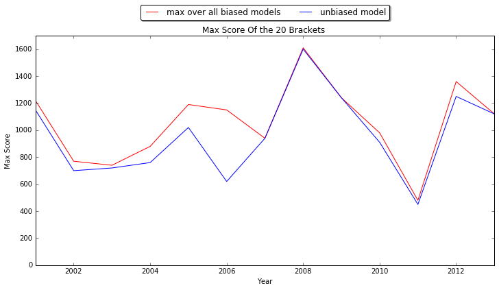

```python
fig = plt.figure(figsize=(12,6))
ax = fig.add_subplot(111)
ax.plot(year_range, max_score, color="r", label="max over all biased models")
ax.plot(year_range, greedy_scores, color="b", label="unbiased model")
ax.set_xlim([2001, 2013])
ax.set_ylim([0, 1700])
ax.set_xlabel("Year")
ax.set_ylabel("Max Score")
ax.set_title("Max Score Of the 20 Brackets ")
ax.legend(loc='lower center', bbox_to_anchor=(0.5, 1.05),
          ncol=3, fancybox=True, shadow=True)

print (np.average(max_score))
```

```python
# uniqueness
n_years = len(greedy_tourneys)
n_biases = len(biases)

bias_unbiased_n_dif = np.zeros((n_years, n_biases))

# iterate through our years
for i in range(n_years):
    for j in range(n_biases):
        # comapre
        bias_unbiased_n_dif[i, j], x, y = biased_tourneys[i][j].compare_to_dif_tournament(actual_tourneys[i], top_seed_tourneys[i], print_res=False)
```

```python
avg_uniqueness = np.average(bias_unbiased_n_dif, axis=0)
print avg_uniqueness[0]
```

```
8.46153846154
```

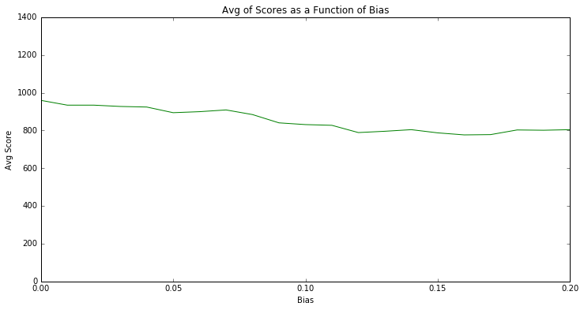

```python
fig = plt.figure(figsize=(12,6))
ax = fig.add_subplot(111)
ax.plot(biases, avg_score, color="g")
ax.set_xlim([0, .2])
ax.set_ylim([0, 1400])
ax.set_xlabel("Bias")
ax.set_ylabel("Avg Score")
ax.set_title("Avg of Scores as a Function of Bias")
ax.legend()
```

Expected score decreases as a function of the amount of bias in the predictions.

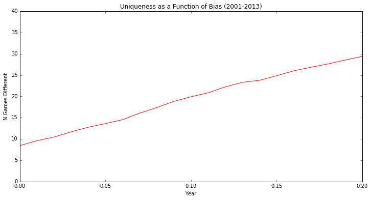

```python
fig = plt.figure(figsize=(12,6))
ax = fig.add_subplot(111)
ax.plot(biases, avg_uniqueness, color="r", label="biased")
ax.set_xlim([0, .2])
ax.set_ylim([0,40])
ax.set_xlabel("Year")
ax.set_ylabel("N Games Different")
ax.set_title("Uniqueness as a Function of Bias (2001-2013)")
```

Uniqueness increases as a function of the bias.

While expected score decreases (slowly) as a function of the amount of bias in the predictions, we can see our uniqueness increases (quickly) as a function of bias. As such, we can make a trade-off between uniquness and expected scoring. This is a good tradeoff to make, we think, because of the game theory element to march madness. We need to pick a bracket different than the competition, otherwise we have no chance to win.

#### See how a biased model performs over the years.

```python
scores_biased_models = np.zeros(max_year-min_year)
```

```python
# fit biased models
biased_tourneys = []
i = 0
for year in year_range:
    # get data needed
    seeds_year = seeds_arr[year-1985]
    slots_year = slots_arr[year-1985]
    games_year = games_arr[year-1985]

    # setup head to head model, with bias
    biased_model = mmm.ModelPredictor(models[i],
                                     scalers[i],
                                     predictor_dfs,
                                     year,
                                     simulation=False,
                                     higher_seed_bias=True,
                                     seeds_df=seeds_year,
                                     higher_seed_bias_delta=.07)


    biased_tourneys.append(mmc.Tournament(seeds_year, slots_year, biased_model, include_scoring_dif=False))

    i = i + 1
```

```python
# score biased models
i = 0
for year in year_range:
    # actual results
    actual_tourney = actual_tourneys[i]

    # get data needed
    seeds_year = seeds_arr[year-1985]
    slots_year = slots_arr[year-1985]
    games_year = games_arr[year-1985]

    # score the biased models
    scores_biased_models[i], x = biased_tourneys[i].score_tournament(actual_tourney)

    i = i + 1
```

```
Avg Score Top Seed : 863.846153846
Avg Score Unbiased : 960.0
Avg Score Biased   : 909.230769231
```

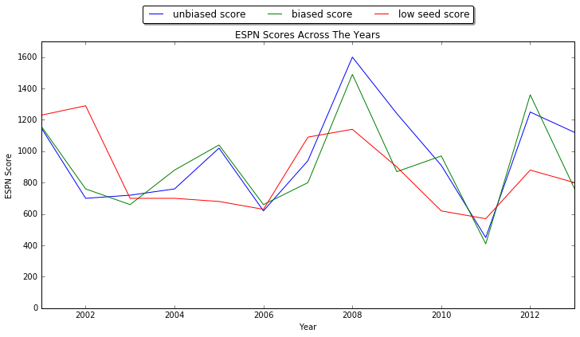

```python
fig = plt.figure(figsize=(12,6))
ax = fig.add_subplot(111)
ax.plot(year_range, greedy_scores, color="b", label="unbiased score")
ax.plot(year_range, scores_biased_models, color="g", label="biased score")
ax.plot(year_range, top_seed_scores, color="r", label="low seed score")
ax.set_xlim([2001, 2013])
ax.set_ylim([0, 1700])
ax.set_xlabel("Year")
ax.set_ylabel("ESPN Score")
ax.set_title("ESPN Scores Across The Years")
ax.legend(loc='lower center', bbox_to_anchor=(0.5, 1.05),
          ncol=3, fancybox=True, shadow=True)


print "Avg Score Top Seed : {}".format(np.average(top_seed_scores))
print "Avg Score Unbiased : {}".format(np.average(greedy_scores))
print "Avg Score Biased   : {}".format(np.average(scores_biased_models))
```

As we can see, the biased model outperforms the unbiased model in some years, while sometimes the unbiased model does better.

```python
n = len(greedy_tourneys)

bias_top_seed_n_dif = np.zeros(n)
bias_top_seed_n_correct = np.zeros(n)
bias_top_seed_n_other_correct = np.zeros(n)

bias_greedy_n_dif = np.zeros(n)
bias_greedy_n_correct = np.zeros(n)
bias_greedy_n_other_correct = np.zeros(n)

# iterate through our entire list
for i in range(n):
    # comapre
    bias_top_seed_n_dif[i], bias_top_seed_n_correct[i], bias_top_seed_n_other_correct[i] = biased_tourneys[i].compare_to_dif_tournament(actual_tourneys[i], top_seed_tourneys[i], print_res=False)

    bias_greedy_n_dif[i], bias_greedy_n_correct[i], bias_greedy_n_other_correct[i] = biased_tourneys[i].compare_to_dif_tournament(actual_tourneys[i], greedy_tourneys[i], print_res=False)
```

```
Avg N Games Dif Unbiased Low Seed : 8.46153846154
Avg N Games Dif Biased Low Seed   : 16.0769230769
```

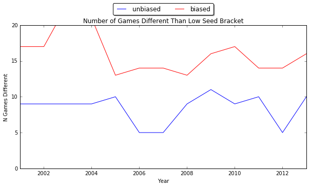

```python
fig = plt.figure(figsize=(10,5))
ax = fig.add_subplot(111)
ax.plot(year_range, greedy_n_dif, color="b", label="unbiased")
ax.plot(year_range, bias_top_seed_n_dif, color="r", label="biased")
ax.set_xlim([2001, 2013])
ax.set_ylim([0,20])
ax.set_xlabel("Year")
ax.set_ylabel("N Games Different")
ax.set_title("Number of Games Different Than Low Seed Bracket")
ax.legend(loc='lower center', bbox_to_anchor=(0.5, 1.05),
          ncol=3, fancybox=True, shadow=True)

print "Avg N Games Dif Unbiased Low Seed : {}".format(np.average(greedy_n_dif))
print "Avg N Games Dif Biased Low Seed   : {}".format(np.average(bias_top_seed_n_dif))
```

## 3) Simulation With Bias

- Test whether adding bias to the simulation method has an effect different than on the greedy model.

```python
biased_simulator_scores = np.zeros(max_year-min_year)
```

```python
reload(mmc)
```

```
<module 'march_madness_classes' from 'march_madness_classes.py'>
```

```python
# fit biased models
biased_simulators = []
i = 0
for year in year_range:
    # get data needed
    seeds_year = seeds_arr[year-1985]
    slots_year = slots_arr[year-1985]
    games_year = games_arr[year-1985]

    # setup head to head model, with bias
    biased_model = mmm.ModelPredictor(models[i],
                                     scalers[i],
                                     predictor_dfs,
                                     year,
                                     simulation=True,
                                     higher_seed_bias=True,
                                     seeds_df=seeds_year,
                                     higher_seed_bias_delta=.04)


    biased_simulators.append(mmc.Simulator(seeds_year, slots_year, biased_model))

    i = i + 1
```

```python
# run simulations
i = 0
for year in year_range:
    # run simulation
    biased_simulators[i].simulate_tournament(300)

    # predict bracket based on the simulation
    biased_simulators[i].predict_tournament()

    i = i + 1

    print year
```

```
2001
2002
2003
2004
2005
2006
2007
2008
2009
2010
2011
2012
2013
```

```python
# analyze results for all simulations
i = 0
year = min_year
for simulator in biased_simulators:
    # get data from our db
    seeds_year = seeds_arr[year-1985]
    slots_year = slots_arr[year-1985]
    games_year = games_arr[year-1985]

    # get actual models
    actual_model = mmm.ActualTournament(games_arr[year-1985])
    actual_tourney = mmc.Tournament(seeds_year, slots_year, actual_model, include_scoring_dif=False)

    # score tournament
    biased_simulator_scores[i], x = simulator.score_tournament(actual_tourney, print_res=False)

    year = year + 1
    i = i + 1
```

[output not shown]

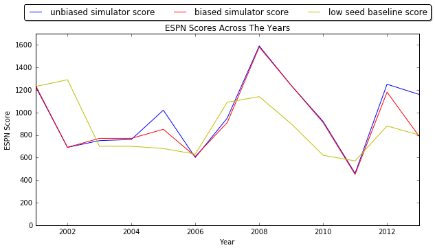

```python
fig = plt.figure(figsize=(10,5))
ax = fig.add_subplot(111)
ax.plot(year_range, simulator_scores, color="b", label="unbiased simulator score")
ax.plot(year_range, biased_simulator_scores, color="r", label="biased simulator score")
ax.plot(year_range, top_seed_scores, color="y", label="low seed baseline score")
ax.set_xlim([2001, 2013])
ax.set_ylim([0, 1700])
ax.set_xlabel("Year")
ax.set_ylabel("ESPN Score")
ax.set_title("ESPN Scores Across The Years")
ax.legend(loc='lower center', bbox_to_anchor=(0.5, 1.05),
          ncol=3, fancybox=True, shadow=True)


print "Avg Score Top Seed           : {}".format(np.average(top_seed_scores))
print "Avg Score Unbiased Simulator : {}".format(np.average(simulator_scores))
print "Avg Score Biased Greedy      : {}".format(np.average(scores_biased_models))
print "Avg Score Biased Simulator   : {}".format(np.average(biased_simulator_scores))
```

The biased simulator and the biased greedy model do almost exactly the same.

```python
n = len(greedy_tourneys)

bias_sim_n_dif = np.zeros(n)
bias_sim_n_correct = np.zeros(n)
bias_sim_n_other_correct = np.zeros(n)


# iterate through our entire list
for i in range(n):
    # comapre
    bias_sim_n_dif[i], bias_sim_n_correct[i], bias_sim_n_other_correct[i] = biased_simulators[i].tournament_prediction.compare_to_dif_tournament(actual_tourneys[i], top_seed_tourneys[i], print_res=False)
```

[output not shown]

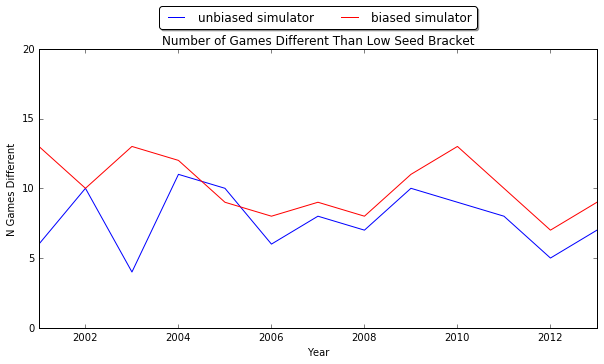

```python
fig = plt.figure(figsize=(10,5))
ax = fig.add_subplot(111)
ax.plot(year_range, simulator_n_dif, color="b", label="unbiased simulator")
ax.plot(year_range, bias_sim_n_dif, color="r", label="biased simulator")
ax.set_xlim([2001, 2013])
ax.set_ylim([0,20])
ax.set_xlabel("Year")
ax.set_ylabel("N Games Different")
ax.set_title("Number of Games Different Than Low Seed Bracket")
ax.legend(loc='lower center', bbox_to_anchor=(0.5, 1.05),
          ncol=3, fancybox=True, shadow=True)

print "Avg N Games Dif Unbiased Sim Low Seed : {}".format(np.average(simulator_n_dif))
print "Avg N Games Dif Biased Sim Low Seed   : {}".format(np.average(bias_sim_n_dif))
```

## 4) Late vs Early Round Upsets

- Another way to increase the uniqueness of brackets is to tune the location of the upsets. For example, predicting a 4 seed to make the final 4 is a unique bracket. However, so is predicting a 13 seed to beat a 4 seed. As such, we test how the model performs when we make the bias a function of the current round.

```python
early_round_upsets = {6:0, 5:0, 4:0, 3:0, 2:20, 1:40}
later_round_upsets = {6:10, 5:10, 4:10, 3:30, 2:20, 1:0}

early_round_upsets_tourneys = []
later_round_upsets_tourneys = []

i = 0
for year in year_range:

    # get data needed
    seeds_year = seeds_arr[year-1985]
    slots_year = slots_arr[year-1985]
    games_year = games_arr[year-1985]

    bias = .005

    # setup head to head model, with bias in the early rounds
    early_round_bias = mmm.ModelPredictor(models[i],
                                      scalers[i],
                                      predictor_dfs,
                                      year,
                                      simulation=False,
                                      higher_seed_bias=True,
                                      seeds_df=seeds_year,
                                      higher_seed_bias_delta=bias,
                                      cooling = early_round_upsets)

    # setup head to head model, with bias in the early rounds
    later_round_bias = mmm.ModelPredictor(models[i],
                                      scalers[i],
                                      predictor_dfs,
                                      year,
                                      simulation=False,
                                      higher_seed_bias=True,
                                      seeds_df=seeds_year,
                                      higher_seed_bias_delta=bias,
                                      cooling = later_round_upsets)


    # run tournaments
    early_round_upsets_tourneys.append(mmc.Tournament(seeds_year, slots_year, early_round_bias, include_scoring_dif=False))
    later_round_upsets_tourneys.append(mmc.Tournament(seeds_year, slots_year, later_round_bias, include_scoring_dif=False))

    i = i + 1
```

```python
scores_early_round_upsets = np.zeros(max_year-min_year)
scores_later_round_upsets = np.zeros(max_year-min_year)

# score biased models with cooling
i = 0
for year in year_range:
    # actual results
    actual_tourney = actual_tourneys[i]

    # get data needed
    seeds_year = seeds_arr[year-1985]
    slots_year = slots_arr[year-1985]
    games_year = games_arr[year-1985]

    # score the biased models
    scores_early_round_upsets[i] = early_round_upsets_tourneys[i].score_tournament(actual_tourney)[0]
    scores_later_round_upsets[i] = later_round_upsets_tourneys[i].score_tournament(actual_tourney)[0]

    i = i + 1
```

```
Avg Score Top Seed           : 863.846153846
Avg Score Unbiased           : 960.0
Avg Score Biased Later Round : 858.461538462
Avg Score Biased Early Round : 916.923076923
```

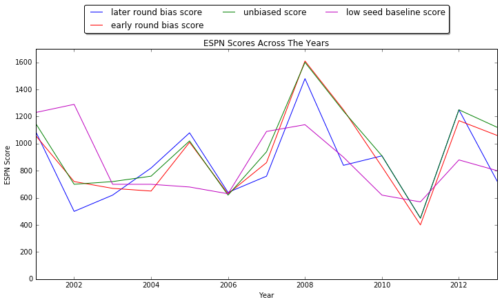

```python
fig = plt.figure(figsize=(12,6))
ax = fig.add_subplot(111)
ax.plot(year_range, scores_later_round_upsets, color="b", label="later round bias score")
ax.plot(year_range, scores_early_round_upsets, color="r", label="early round bias score")
ax.plot(year_range, greedy_scores, color="g", label="unbiased score")
ax.plot(year_range, top_seed_scores, color="m", label="low seed baseline score")
ax.set_xlim([2001, 2013])
ax.set_ylim([0, 1700])
ax.set_xlabel("Year")
ax.set_ylabel("ESPN Score")
ax.set_title("ESPN Scores Across The Years")
ax.legend(loc='lower center', bbox_to_anchor=(0.5, 1.05),
          ncol=3, fancybox=True, shadow=True)


print "Avg Score Top Seed           : {}".format(np.average(top_seed_scores))
print "Avg Score Unbiased           : {}".format(np.average(greedy_scores))
print "Avg Score Biased Later Round : {}".format(np.average(scores_later_round_upsets))
print "Avg Score Biased Early Round : {}".format(np.average(scores_early_round_upsets))
```

Having bias in the model in the early rounds seems to do better than in the later rounds. This makes sense, becuase once we get to the later rounds, our model should be a good ranking of the teams. But adding some "flare" to our predictions in the early rounds may increase our scores.

```python
n = len(greedy_tourneys)

early_late_n_dif = np.zeros(n)

# iterate through our entire list
for i in range(n):
    # comapre
    early_late_n_dif[i], x, y = early_round_upsets_tourneys[i].compare_to_dif_tournament(actual_tourneys[i], later_round_upsets_tourneys[i], print_res=False)
```

```python
np.average(early_late_n_dif)
```

```
18.307692307692307
```

```
Avg N Games Dif : 18.3076923077
```

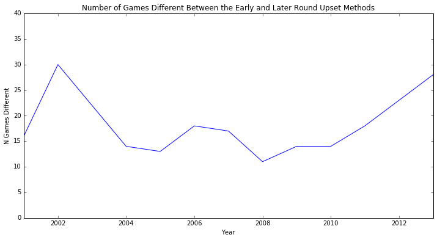

```python
fig = plt.figure(figsize=(12,6))
ax = fig.add_subplot(111)
ax.plot(year_range, early_late_n_dif, color="b", label="unbiased simulator")
ax.set_xlim([2001, 2013])
ax.set_ylim([0,40])
ax.set_xlabel("Year")
ax.set_ylabel("N Games Different")
ax.set_title("Number of Games Different Between the Early and Later Round Upset Methods")

print "Avg N Games Dif : {}".format(np.average(early_late_n_dif))
```

Plotted above is the number of games different between the early and late round upset brackets. As we can see, there is a lot of diversity between the two brackets. As such, if we are submitting to ESPN, in which we are allowed 10 submissions, it makes sense to submit 10 diverse brackets. See "Modeling- Ensemble Of Brackets.ipynb" for an analysis of this method.